# Final Project - Spotify Popularity Song Prediction

Team 1

2026-04-21

```r
#load libraries and set theme with Spotify colors
library(janitor)
library(dplyr)
library(caret)
library(C50)
library(class)
library(randomForest)
library(neuralnet)
library(kernlab)
library(knitr)
```

```r
library(ggplot2)
library(tidyr)
library(scales)
library(partykit)
theme_spotify <- function() {
  theme_minimal(base_size = 12) +
    theme(
      plot.background = element_rect(fill = "#121212", color = NA),
      panel.background = element_rect(fill = "#181818", color = NA),
      panel.border = element_blank(),
      panel.grid.major = element_line(color = "#2A2A2A", linewidth = 0.4),
      panel.grid.minor = element_blank(),
      axis.text = element_text(color = "#B3B3B3"),
      axis.title = element_text(color = "#F5F5F5", face = "bold"),
      plot.title = element_text(color = "#1DB954", face = "bold", size = 16),
      plot.subtitle = element_text(color = "#D9D9D9", size = 11),
      plot.caption = element_text(color = "#B3B3B3", size = 9),
      legend.background = element_rect(fill = "#181818", color = NA),
      legend.box.background = element_rect(fill = "#181818", color = NA),
      legend.key = element_rect(fill = "#181818", color = NA),
      legend.text = element_text(color = "#F5F5F5"),
      legend.title = element_text(color = "#1DB954", face = "bold"),
      strip.background = element_rect(fill = "#1DB954", color = NA),
      strip.text = element_text(color = "#121212", face = "bold")
    )
}
```

### Introduction

The purpose of this project is to predict whether a Spotify song will be classified as popular or not popular using measurable song characteristics. In a business setting, this type of model can help music platforms, production companies, and music marketers understand which song attributes are associated with stronger audience appeal. The analysis uses data obtained from Kaggle and machine learning techniques to identify patterns linked to popularity outcomes.

The predictor variables in this project are the song-level variables that may help explain popularity, such as acousticness, danceability, energy, loudness, speechiness, valence, tempo, and genre-related indicators. These variables capture different dimensions of how a song sounds, feels, and is categorized, making them reasonable candidates for a popularity prediction task. The intent is to test whether combinations of these musical features can separate more popular songs from less popular ones.

We begin by building several first-level classification models, including logistic regression, k-nearest neighbors (kNN), decision trees, random forests, artificial neural networks (ANN), and support vector machines (SVM). Beyond the first-level models, we implement a stacked modeling approach. Specifically, we use the predicted probabilities from the first-level models as inputs into a second-level model, allowing the stacked model to learn how to optimally combine information across different modeling approaches.

We evaluate model performance not only in terms of statistical accuracy, but also in terms of business-relevant outcomes, such as the ability to rank songs and concentrate success among top selections. This framing reflects how decisions are made in practice, where the goal is not perfect prediction, but better prioritization.

From a managerial perspective, we place greater emphasis on correctly identifying popular songs than on avoiding false positives. Missing a truly popular song may lead to lost opportunities for recommendation exposure, playlist placement, and user engagement, whereas overestimating a song’s popularity results in relatively smaller inefficiencies.

### Getting Data

The dataset used in this analysis contains a wide range of Spotify song-level characteristics for 176,774 songs. Each observation represents an individual track and includes information on genre, as well as several acoustic features such as danceability, energy, loudness, tempo, valence, and instrumentalness.

The primary outcome variable is a song’s popularity score, which reflects its relative performance on the platform. To frame this as a classification problem, we convert the continuous popularity measure into a binary variable, where songs with popularity at or above the median are labeled as “popular,” and those below the median are labeled as “not popular.” This transformation allows us to evaluate model performance using standard classification metrics such as accuracy, Kappa, and sensitivity.

```r
spotify <- read.csv("SpotifyFeatures.csv", stringsAsFactors = TRUE)
```

### Cleaning Data

Prior to modeling, we perform several data preparation steps. We first check for missing values and find none in the dataset. We then retain only the variables needed for the analysis, including track ID, genre, popularity, and the selected acoustic features. Although artist name could be useful in predicting popularity, we exclude it from the analysis because representing each unique artist would require a very large number of dummy variables. Excluding artist also keeps the focus on the characteristics of the songs themselves rather than the reputation of the performers.

Next, we convert genre into dummy variables so that it can be used in the machine learning models. Because multiple rows may correspond to the same track, we then collapse the data to one row per unique track using track_id. After that, we transform the popularity variable into a binary outcome based on the sample median. Converting popularity into a binary classification allows us to evaluate model performance using confusion matrices and related metrics such as accuracy, kappa, and sensitivity. In this study, songs with popularity at or above the median are coded as 1, and songs below the median are coded as 0.

Finally, for models that are sensitive to feature scale, such as kNN, neural networks, and SVM, we apply min-max normalization so that all predictors are measured on a comparable scale.

```r
summary(spotify)
```

```
##         genre                         artist_name       track_name
##  Comedy    :  9681   Giuseppe Verdi         :  1394   Home   :   100
##  Soundtrack:  9646   Giacomo Puccini        :  1137   You    :    71
##  Indie     :  9543   Kimbo Children's Music :   971   Intro  :    69
##  Jazz      :  9441   Nobuo Uematsu          :   825   Stay   :    63
##  Pop       :  9386   Richard Wagner         :   804   Wake Up:    59
##  Electronic:  9377   Wolfgang Amadeus Mozart:   800   Closer :    58
##  (Other)   :175651   (Other)                :226794   (Other):232305
##                    track_id        popularity      acousticness
##  0UE0RhnRaEYsiYgXpyLoZc:     8   Min.   :  0.00   Min.   :0.0000
##  0wY9rA9fJkuESyYm9uzVK5:     8   1st Qu.: 29.00   1st Qu.:0.0376
##  3R73Y7X53MIQZWnKloWq5i:     8   Median : 43.00   Median :0.2320
##  3uSSjnDMmoyERaAK9KvpJR:     8   Mean   : 41.13   Mean   :0.3686
##  6AIte2Iej1QKlaofpjCzW1:     8   3rd Qu.: 55.00   3rd Qu.:0.7220
##  6sVQNUvcVFTXvlk3ec0ngd:     8   Max.   :100.00   Max.   :0.9960
##  (Other)               :232677
##   danceability     duration_ms          energy         instrumentalness
##  Min.   :0.0569   Min.   :  15387   Min.   :2.03e-05   Min.   :0.0000000
##  1st Qu.:0.4350   1st Qu.: 182857   1st Qu.:3.85e-01   1st Qu.:0.0000000
##  Median :0.5710   Median : 220427   Median :6.05e-01   Median :0.0000443
##  Mean   :0.5544   Mean   : 235122   Mean   :5.71e-01   Mean   :0.1483012
##  3rd Qu.:0.6920   3rd Qu.: 265768   3rd Qu.:7.87e-01   3rd Qu.:0.0358000
##  Max.   :0.9890   Max.   :5552917   Max.   :9.99e-01   Max.   :0.9990000
##
##       key           liveness          loudness          mode
##  C      :27583   Min.   :0.00967   Min.   :-52.457   Major:151744
##  G      :26390   1st Qu.:0.09740   1st Qu.:-11.771   Minor: 80981
##  D      :24077   Median :0.12800   Median : -7.762
##  C#     :23201   Mean   :0.21501   Mean   : -9.570
##  A      :22671   3rd Qu.:0.26400   3rd Qu.: -5.501
##  F      :20279   Max.   :1.00000   Max.   :  3.744
##  (Other):88524
##   speechiness         tempo        time_signature    valence
##  Min.   :0.0222   Min.   : 30.38   0/4:     8     Min.   :0.0000
##  1st Qu.:0.0367   1st Qu.: 92.96   1/4:  2608     1st Qu.:0.2370
##  Median :0.0501   Median :115.78   3/4: 24111     Median :0.4440
##  Mean   :0.1208   Mean   :117.67   4/4:200760     Mean   :0.4549
##  3rd Qu.:0.1050   3rd Qu.:139.05   5/4:  5238     3rd Qu.:0.6600
##  Max.   :0.9670   Max.   :242.90                  Max.   :1.0000
##
```

```r
str(spotify)
```

```
## 'data.frame':    232725 obs. of  18 variables:
##  $ genre           : Factor w/ 27 levels "A Capella","Alternative",..: 16 16 16 16 16 16 16 16 16 16 ...
##  $ artist_name     : Factor w/ 14564 levels "'Til Tuesday",..: 5256 8327 6545 5256 4113 5256 8327 7401 2436 7436 ...
##  $ track_name      : Factor w/ 148615 levels "' Cello Song",..: 18584 93903 32511 31332 91776 69420 97152 70726 50881 70019 ...
##  $ track_id        : Factor w/ 176774 levels "00021Wy6AyMbLP2tqij86e",..: 4971 4768 5608 8233 10160 12589 13641 14649 17254 19465 ...
##  $ popularity      : int  0 1 3 0 4 0 2 15 0 10 ...
##  $ acousticness    : num  0.611 0.246 0.952 0.703 0.95 0.749 0.344 0.939 0.00104 0.319 ...
##  $ danceability    : num  0.389 0.59 0.663 0.24 0.331 0.578 0.703 0.416 0.734 0.598 ...
##  $ duration_ms     : int  99373 137373 170267 152427 82625 160627 212293 240067 226200 152694 ...
##  $ energy          : num  0.91 0.737 0.131 0.326 0.225 0.0948 0.27 0.269 0.481 0.705 ...
##  $ instrumentalness: num  0 0 0 0 0.123 0 0 0 0.00086 0.00125 ...
##  $ key             : Factor w/ 12 levels "A","A#","B","C",..: 5 10 4 5 9 5 5 10 4 11 ...
##  $ liveness        : num  0.346 0.151 0.103 0.0985 0.202 0.107 0.105 0.113 0.0765 0.349 ...
##  $ loudness        : num  -1.83 -5.56 -13.88 -12.18 -21.15 ...
##  $ mode            : Factor w/ 2 levels "Major","Minor": 1 2 2 1 1 1 1 1 1 1 ...
##  $ speechiness     : num  0.0525 0.0868 0.0362 0.0395 0.0456 0.143 0.953 0.0286 0.046 0.0281 ...
##  $ tempo           : num  167 174 99.5 171.8 140.6 ...
##  $ time_signature  : Factor w/ 5 levels "0/4","1/4","3/4",..: 4 4 5 4 4 4 4 4 4 4 ...
##  $ valence         : num  0.814 0.816 0.368 0.227 0.39 0.358 0.533 0.274 0.765 0.718 ...
```

```r
# checking for NAs
colSums(is.na(spotify))
```

```
##            genre      artist_name       track_name         track_id
##                0                0                0                0
##       popularity     acousticness     danceability      duration_ms
##                0                0                0                0
##           energy instrumentalness              key         liveness
##                0                0                0                0
##         loudness             mode      speechiness            tempo
##                0                0                0                0
##   time_signature          valence
##                0                0
```

```r
# keep only variables needed for aggregation
spotify <- spotify %>%
  dplyr::select(
    track_id, genre, popularity, acousticness, danceability, duration_ms,
    energy, instrumentalness, key, liveness, loudness, mode,
    speechiness, tempo, time_signature, valence
  )

# create genre dummies
genre_dummies <- as.data.frame(model.matrix(~ genre - 1, data = spotify)) %>%
  clean_names()

# bind dummies
spotify <- bind_cols(spotify, genre_dummies)

# collapse to one row per song
spotify <- spotify %>%
  group_by(track_id) %>%
  summarise(
    popularity = first(popularity),
    acousticness = first(acousticness),
    danceability = first(danceability),
    duration_ms = first(duration_ms),
    energy = first(energy),
    instrumentalness = first(instrumentalness),
    key = first(key),
    liveness = first(liveness),
    loudness = first(loudness),
    mode = first(mode),
    speechiness = first(speechiness),
    tempo = first(tempo),
    time_signature = first(time_signature),
    valence = first(valence),
    across(starts_with("genre_"), max),
    .groups = "drop"
  )

# create binary outcome using median
median_popularity <- median(spotify$popularity, na.rm = TRUE)

spotify <- spotify %>%
  mutate(popular_binary = if_else(popularity >= median_popularity, 1, 0)) %>%
  select(-track_id, -popularity)

# create dummy matrix (this becomes your main modeling dataset)
spotify_dummy <- as.data.frame(model.matrix(~ . - 1, data = spotify)) %>%
  clean_names()

# merge the two columns
spotify_dummy$genre_childrens_music <-
  pmax(
    spotify_dummy$genre_childrens_music,
    spotify_dummy$genre_children_s_music,
    na.rm = TRUE
  )

# drop the duplicate column
spotify_dummy$genre_children_s_music <- NULL

# min-max scaling
minmax <- function(x) {
  if (max(x) == min(x)) rep(0, length(x)) else (x - min(x)) / (max(x) - min(x))
}

spotify_scale <- as.data.frame(lapply(spotify_dummy, minmax))
```

### Examining Data

Before moving into predictive modeling, we examine the data to better understand its underlying patterns. This exploratory analysis helps us assess class balance, review the genre distribution, and visualize how song characteristics vary across categories.

#### Class Balance

First, we examine class balance. The table shows that there are 86,270 “not popular” (0) songs and 90,504 “popular” (1) songs, corresponding to proportions of 48.8% and 51.2%, respectively. This indicates that the outcome classes are well balanced, which is helpful for model estimation and evaluation.

```r
table(spotify_dummy$popular_binary)
```

```
##
##     0     1
## 86270 90504
```

```r
prop.table(table(spotify_dummy$popular_binary))
```

```
##
##         0         1
## 0.4880243 0.5119757
```

#### Summary Statistics

```r
summary(
  spotify %>%
    dplyr::select(
      acousticness, danceability, duration_ms, energy, instrumentalness,
      liveness, loudness, speechiness, tempo, valence
    )
)
```

```
##   acousticness     danceability     duration_ms          energy
##  Min.   :0.0000   Min.   :0.0569   Min.   :  15387   Min.   :2.03e-05
##  1st Qu.:0.0456   1st Qu.:0.4150   1st Qu.: 178253   1st Qu.:3.44e-01
##  Median :0.2880   Median :0.5580   Median : 219453   Median :5.92e-01
##  Mean   :0.4041   Mean   :0.5411   Mean   : 236127   Mean   :5.57e-01
##  3rd Qu.:0.7910   3rd Qu.:0.6830   3rd Qu.: 268547   3rd Qu.:7.89e-01
##  Max.   :0.9960   Max.   :0.9890   Max.   :5552917   Max.   :9.99e-01
##  instrumentalness       liveness          loudness        speechiness
##  Min.   :0.0000000   Min.   :0.00967   Min.   :-52.457   Min.   :0.0222
##  1st Qu.:0.0000000   1st Qu.:0.09750   1st Qu.:-12.851   1st Qu.:0.0368
##  Median :0.0000704   Median :0.13000   Median : -8.191   Median :0.0494
##  Mean   :0.1720729   Mean   :0.22453   Mean   :-10.138   Mean   :0.1274
##  3rd Qu.:0.0908000   3rd Qu.:0.27700   3rd Qu.: -5.631   3rd Qu.:0.1020
##  Max.   :0.9990000   Max.   :1.00000   Max.   :  3.744   Max.   :0.9670
##      tempo           valence
##  Min.   : 30.38   Min.   :0.0000
##  1st Qu.: 92.01   1st Qu.:0.2220
##  Median :115.01   Median :0.4400
##  Mean   :117.20   Mean   :0.4516
##  3rd Qu.:138.80   3rd Qu.:0.6670
##  Max.   :242.90   Max.   :1.0000
```

#### Genre Distribution

Next, we examine the top 15 genres and visualize them using a bar chart. The goal of this analysis is to identify whether any genres dominate the dataset. This is important because a high concentration of songs within one or two genres could disproportionately influence model results. The plot shows that the top 15 genres are relatively similar in size, suggesting that no single genre overwhelmingly drives the dataset.

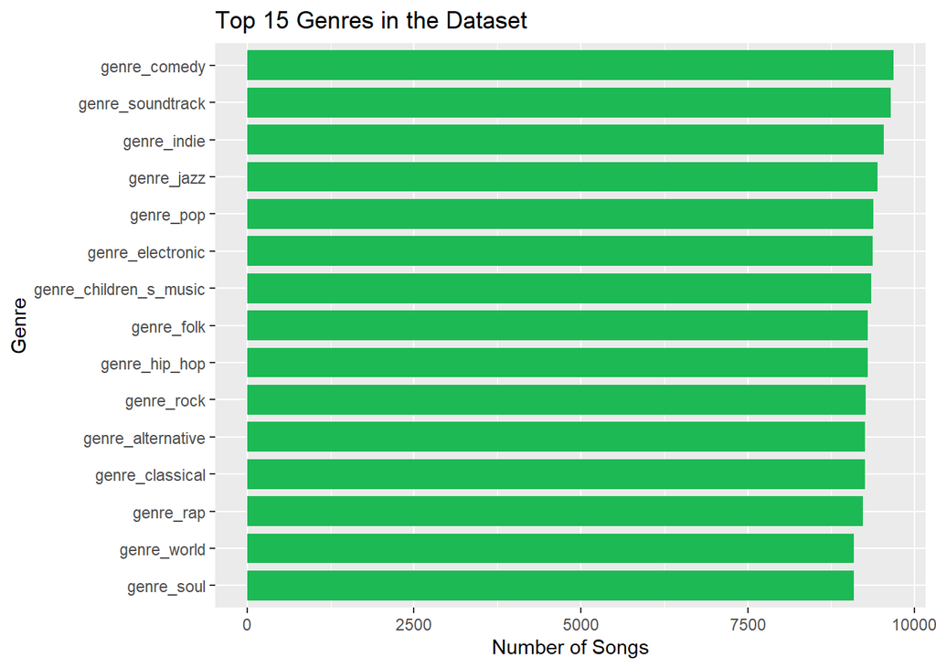

```r
#finding the most frequent genres

top_genres <- spotify %>%
  summarise(across(starts_with("genre_"), sum)) %>%
  pivot_longer(cols = everything(), names_to = "genre", values_to = "n") %>%
  arrange(desc(n)) %>%
  slice_head(n = 15)

#plotting the top genres
ggplot(top_genres, aes(x = reorder(genre, n), y = n)) +
  geom_col(fill = "#1DB954", width = 0.8) +
  coord_flip() +
  labs(
    title = "Top 15 Genres in the Dataset",
    x = "Genre", y = "Number of Songs"
  )
```

We also examine the top 15 genres by average popularity to understand which genres tend to perform best, independent of their frequency in the dataset. The results show that genres such as Rap, Hip Hop, and Pop are more likely to produce songs classified as popular.

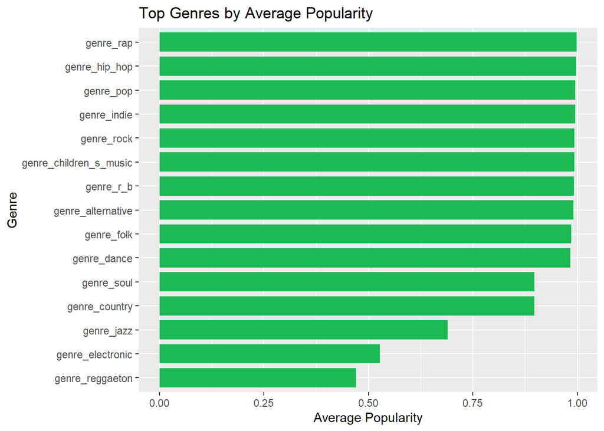

```r
#comparing average popularity across genres
genre_popularity <- spotify %>%
  select(popular_binary, starts_with("genre_")) %>%
  pivot_longer(cols = starts_with("genre_"),
               names_to = "genre",
               values_to = "has_genre") %>%
  filter(has_genre == 1) %>%
  group_by(genre) %>%
  summarise(
    avg_popularity = mean(popular_binary),
    count = n(),
    .groups = "drop") %>%
  arrange(desc(avg_popularity)) %>%
  slice_head(n = 15)

ggplot(genre_popularity, aes(x = reorder(genre, avg_popularity), y = avg_popularity)) +
  geom_col(fill = "#1DB954", width = 0.8) +
  coord_flip() +
  labs(
    title = "Top Genres by Average Popularity",
    x = "Genre", y = "Average Popularity"
  )
```

#### Feature Patterns Across Genres

Next, we analyze genre-level characteristics by aggregating key song features within each genre. Specifically, we calculate average values of danceability, energy, valence, acousticness, loudness, and tempo, along with the number of songs in each genre. This allows us to identify systematic differences across genres. For example, some genres tend to be more energetic and danceable, while others are more acoustic or subdued. For brevity, only a subset of genres is shown in the output.

```r
genre_feature_summary <- spotify %>%
  pivot_longer(cols = starts_with("genre_"),
               names_to = "genre",
               values_to = "has_genre") %>%
  filter(has_genre == 1) %>%
  group_by(genre) %>%
  summarise(
    danceability = mean(danceability),
    energy = mean(energy),
    valence = mean(valence),
    acousticness = mean(acousticness),
    loudness = mean(loudness),
    tempo = mean(tempo),
    count = n(),
    .groups = "drop"
  )

head(genre_feature_summary)
```

```
## # A tibble: 6 × 8
##   genre            danceability energy valence acousticness loudness tempo count
##   <chr>                   <dbl>  <dbl>   <dbl>        <dbl>    <dbl> <dbl> <int>
## 1 genre_a_capella         0.412  0.250   0.329        0.830   -13.7   112.   119
## 2 genre_alternati…        0.542  0.712   0.450        0.162    -6.54  123.  9263
## 3 genre_anime             0.472  0.665   0.442        0.287    -7.92  127.  8936
## 4 genre_blues             0.528  0.606   0.579        0.328    -9.05  121.  9023
## 5 genre_children_…        0.542  0.707   0.449        0.163    -6.53  122.  9353
## 6 genre_childrens…        0.697  0.397   0.676        0.592   -11.6   121.  5403
```

#### Correlation Analysis

Finally, we construct a correlation matrix to examine relationships among the song characteristics. This helps identify which features tend to move together and provides insight into potential multicollinearity in the dataset.

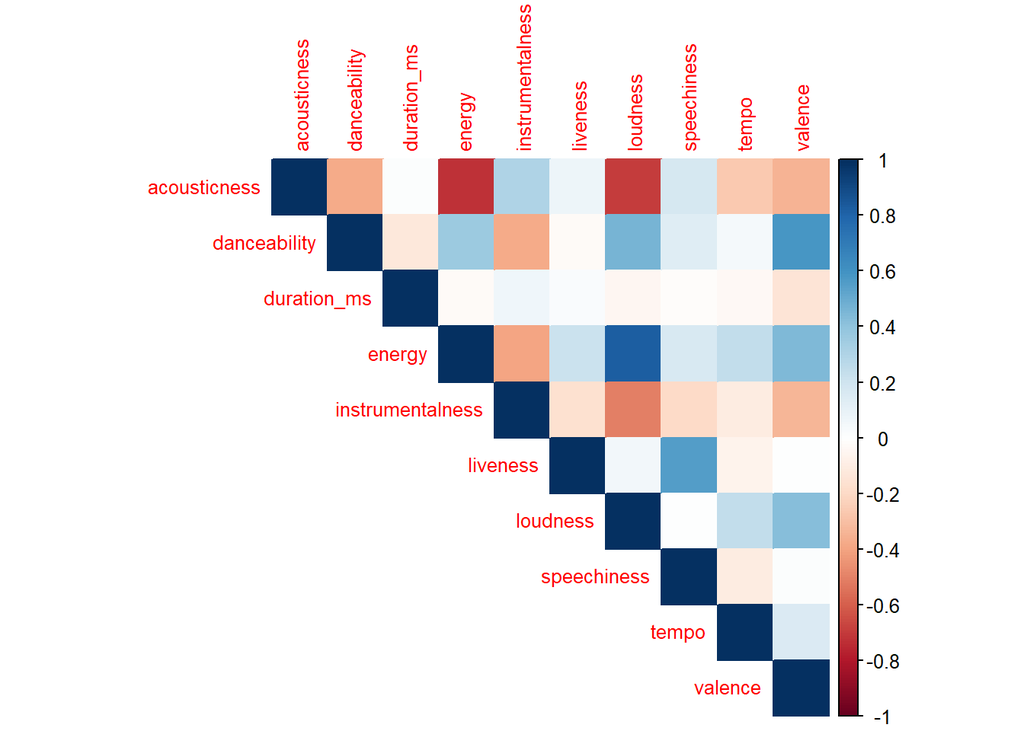

```r
numeric_features <- spotify %>%
  dplyr::select(
    acousticness, danceability, duration_ms, energy, instrumentalness,
    liveness, loudness, speechiness, tempo, valence)

cor_matrix <- cor(numeric_features, use = "complete.obs")

corrplot::corrplot(cor_matrix, method = "color", type = "upper", tl.cex = 0.8)
```

The correlation matrix reveals several meaningful relationships among song features. Energy and loudness are strongly positively correlated, which is intuitive since louder songs tend to be more energetic. Acousticness is strongly negatively correlated with both energy and loudness, reflecting that more acoustic songs are typically quieter and less intense. Danceability also shows moderate positive correlations with energy and valence, suggesting that more upbeat and energetic songs are more likely to be danceable.

Overall, while some features are moderately correlated, there is no evidence of severe multicollinearity. This indicates that most variables provide distinct information, which is beneficial for model performance, particularly for models that assume independence across predictors, such as logistic regression.

#### Key Takeaways

The exploratory data analysis suggests that the prediction problem is well-structured, primarily because the target classes are highly balanced. After converting popularity into a binary outcome, the dataset contains approximately 48.8% “not popular” songs and 51.2% “popular” songs, meaning neither class dominates the sample. This is important from both a statistical and business perspective, as it reduces the risk that model performance is driven by class imbalance rather than meaningful differences in song characteristics. The summary statistics further indicate that the typical song in the dataset is moderately danceable, moderately energetic, and approximately 3.7 minutes long, providing a useful baseline for what a “representative” track looks like.

A second major takeaway is that the dataset is not heavily concentrated in just one genre, at least among the top categories. The top 15 genres are relatively similar in size, which helps ensure that results are not disproportionately driven by one category. At the same time, the genre-level summaries show that musical features vary meaningfully across categories. For example, classical songs have much lower danceability and energy but much higher acousticness, while children’s music appears more upbeat and accessible on average. This tells us that genre is likely to matter in predicting popularity, not only because genres differ in audience appeal, but also because they capture underlying differences in the musical profile of songs.

The correlation analysis reinforces that popularity is influenced by a combination of features rather than any single variable. While some relationships are evident, such as a strong positive correlation between energy and loudness, and negative correlations between acousticness and those same variables, no correlations are extreme. This indicates that multicollinearity is unlikely to be a major concern and that most features provide distinct information for prediction.

Overall, these findings suggest that song popularity is not random but is systematically related to measurable characteristics and genre-specific patterns. For managers, this implies that data-driven approaches can meaningfully improve decision-making, particularly in identifying songs with higher potential for success.

### Splitting Data

To evaluate model performance, we partition the dataset into training and test sets. Specifically, we randomly assign 50% of the observations to the training set and the remaining 50% to the test set for the first-level models; with the stacked model, we use a 70%/30% split to create our training and validation samples. We maintain two versions of the data throughout this process: a non-scaled dataset for models that do not require feature normalization, such as logistic regression, decision trees, and random forests, and a scaled dataset for models that are sensitive to differences in feature magnitude, such as k-nearest neighbors (kNN), neural networks, and support vector machines (SVM). Both versions use the same train-test split so that model comparisons are based on identical observations. For the scaled version, normalization is performed after the train-test split, preventing information from the test set from influencing preprocessing, helping us avoid data leakage.

```r
ratio <- 0.5
set.seed(12345)
train_rows <- sample(1:nrow(spotify_dummy), ratio * nrow(spotify_dummy))

spotify_train <- spotify_dummy[train_rows, ]
spotify_test  <- spotify_dummy[-train_rows, ]

minmax_from_train <- function(train, test) {
  mins <- sapply(train, min)
  maxs <- sapply(train, max)

  scale_one <- function(x, mn, mx) {
    if (mx == mn) rep(0, length(x)) else (x - mn) / (mx - mn)
  }

  train_scaled <- as.data.frame(Map(scale_one, train, mins, maxs))
  test_scaled  <- as.data.frame(Map(scale_one, test, mins, maxs))

  list(train = train_scaled, test = test_scaled)
}

x_train <- spotify_train[, names(spotify_train) != "popular_binary"]
x_test  <- spotify_test[, names(spotify_test) != "popular_binary"]

scaled <- minmax_from_train(x_train, x_test)

spotify_scale_train <- scaled$train
spotify_scale_test  <- scaled$test

spotify_scale_train$popular_binary <- spotify_train$popular_binary
spotify_scale_test$popular_binary  <- spotify_test$popular_binary
```

### Model Development

We estimate a range of classification models that vary in flexibility and underlying assumptions. These models allow us to compare linear, nonlinear, and distance-based approaches to predicting song popularity. Where available, we use predicted probabilities; for models that do not natively produce them, we construct comparable probability-like measures.

#### Logistic Regression

Logistic regression serves as a baseline model for this analysis. It estimates the probability that a song is popular as a function of its features, assuming a linear relationship between the predictors and the log-odds of popularity. In this specification, all available predictors are included in the model, allowing us to evaluate the marginal contribution of each feature while holding others constant.

```r
logistic_model <- glm(popular_binary ~ ., data=spotify_train, family = "binomial")
summary(logistic_model)
```

```
##
## Call:
## glm(formula = popular_binary ~ ., family = "binomial", data = spotify_train)
##
## Coefficients: (1 not defined because of singularities)
##                         Estimate Std. Error z value Pr(>|z|)
## (Intercept)            2.349e+00  1.162e+00   2.022  0.04318 *
## acousticness          -1.577e-01  4.882e-02  -3.230  0.00124 **
## danceability           1.877e-01  8.277e-02   2.268  0.02332 *
## duration_ms            2.399e-07  7.637e-08   3.142  0.00168 **
## energy                 1.973e-01  8.596e-02   2.295  0.02172 *
## instrumentalness      -3.915e-01  3.942e-02  -9.931  < 2e-16 ***
## key_a                 -7.348e-02  5.073e-02  -1.449  0.14746
## key_a_number          -6.143e-02  5.543e-02  -1.108  0.26778
## key_b                 -7.956e-02  5.458e-02  -1.458  0.14490
## key_c                 -6.840e-02  4.930e-02  -1.387  0.16534
## key_c_number          -2.296e-02  5.197e-02  -0.442  0.65858
## key_d                 -1.103e-01  5.055e-02  -2.182  0.02908 *
## key_d_number           1.716e-02  7.007e-02   0.245  0.80648
## key_e                 -4.824e-02  5.401e-02  -0.893  0.37175
## key_f                 -1.142e-01  5.230e-02  -2.184  0.02896 *
## key_f_number           7.297e-02  5.662e-02   1.289  0.19747
## key_g                 -1.058e-01  4.917e-02  -2.152  0.03142 *
## key_g_number                  NA         NA      NA       NA
## liveness              -3.951e-01  5.840e-02  -6.765 1.33e-11 ***
## loudness               1.869e-02  3.251e-03   5.749 9.00e-09 ***
## mode_minor             1.153e-01  2.164e-02   5.329 9.87e-08 ***
## speechiness           -8.568e-01  1.159e-01  -7.393 1.44e-13 ***
## tempo                 -2.780e-04  3.305e-04  -0.841  0.40022
## time_signature1_4     -3.323e+00  1.159e+00  -2.867  0.00414 **
## time_signature3_4     -3.189e+00  1.156e+00  -2.759  0.00579 **
## time_signature4_4     -3.169e+00  1.155e+00  -2.742  0.00610 **
## time_signature5_4     -3.265e+00  1.157e+00  -2.822  0.00478 **
## valence               -5.777e-01  5.457e-02 -10.587  < 2e-16 ***
## genre_a_capella       -1.118e+01  4.573e+01  -0.245  0.80681
## genre_alternative      5.247e+00  1.580e-01  33.216  < 2e-16 ***
## genre_anime           -8.488e-01  6.565e-02 -12.929  < 2e-16 ***
## genre_blues            1.114e-01  5.910e-02   1.884  0.05952 .
## genre_childrens_music -4.736e-01  7.176e-02  -6.600 4.11e-11 ***
## genre_classical        7.895e-01  5.950e-02  13.270  < 2e-16 ***
```

[output cut: 15 more lines]

```
## genre_rock             4.773e+00  1.734e-01  27.527  < 2e-16 ***
## genre_ska             -1.513e-01  5.902e-02  -2.564  0.01034 *
## genre_soul             2.738e+00  6.774e-02  40.414  < 2e-16 ***
## genre_soundtrack       9.626e-01  5.985e-02  16.085  < 2e-16 ***
## genre_world            6.442e-01  5.445e-02  11.831  < 2e-16 ***
## ---
## Signif. codes:  0 '***' 0.001 '**' 0.01 '*' 0.05 '.' 0.1 ' ' 1
##
## (Dispersion parameter for binomial family taken to be 1)
##
##     Null deviance: 122488  on 88386  degrees of freedom
## Residual deviance:  63650  on 88334  degrees of freedom
## AIC: 63756
##
## Number of Fisher Scoring iterations: 11
```

#### KNN

The kNN model classifies songs based on the labels of the most similar observations in the training data. Using a distance-based approach, it assigns class probabilities based on the proportion of neighbors belonging to each class. We set k=7, balancing sensitivity to local patterns with prediction stability. Because kNN relies on distance calculations, all predictors are normalized.

```r
knn_model <- knn(
  train = spotify_scale_train[, !(names(spotify_scale_train) %in% c("popular_binary"))],
  test  = spotify_scale_test[, !(names(spotify_scale_test) %in% c("popular_binary"))],
  cl    = as.factor(spotify_scale_train$popular_binary), k = 7, prob  = TRUE)

summary(knn_model)
```

```
##     0     1
## 46572 41815
```

#### Decision Tree

The decision tree model creates a set of decision rules that classify songs as popular or not. This approach allows us to understand which features, such as genre or acoustic attributes, are most influential in determining popularity. For our model, we use the C5.0 algorithm.

```r
dt_model <- C5.0(as.factor(popular_binary) ~ ., data = spotify_train)
summary(dt_model)
```

```
##
## Call:
## C5.0.formula(formula = as.factor(popular_binary) ~ ., data = spotify_train)
##
##
## C5.0 [Release 2.07 GPL Edition]      Tue Apr 21 21:55:58 2026
## -------------------------------
##
## Class specified by attribute `outcome'
##
## Read 88387 cases (54 attributes) from undefined.data
##
## Decision tree:
##
## genre_rap > 0: 1 (4646/9)
## genre_rap <= 0:
## :...genre_indie > 0: 1 (4434/21)
##     genre_indie <= 0:
##     :...genre_rock > 0: 1 (3291/32)
##         genre_rock <= 0:
##         :...genre_r_b > 0: 1 (3218/33)
##             genre_r_b <= 0:
##             :...genre_folk > 0: 1 (2641/47)
##                 genre_folk <= 0:
##                 :...genre_alternative > 0: 1 (2347/43)
##                     genre_alternative <= 0:
##                     :...genre_dance > 0: 1 (2230/63)
##                         genre_dance <= 0:
##                         :...genre_hip_hop > 0: 1 (1219/2)
##                             genre_hip_hop <= 0:
##                             :...genre_pop > 0: 1 (797/2)
##                                 genre_pop <= 0:
##                                 :...genre_country > 0: 1 (3293/443)
##                                     genre_country <= 0:
##                                     :...genre_soul > 0:
##                                         :...genre_blues <= 0: 1 (2562/351)
##                                         :   genre_blues > 0:
##                                         :   :...duration_ms <= 210673: 1 (157/30)
##                                         :       duration_ms > 210673:
##                                         :       :...genre_jazz <= 0: 0 (88/25)
```

[output cut: 185 more lines]

```
##    3.56% acousticness
##    3.33% valence
##    1.14% key_b
##    1.10% liveness
##    0.86% key_f_number
##    0.78% key_g_number
##    0.64% danceability
##    0.51% time_signature4_4
##    0.41% key_c_number
##    0.28% key_f
##    0.18% key_a
##    0.09% tempo
##
##
## Time: 6.4 secs
```

[figure not shown]

#### Random Forest

Random forest builds on the decision tree framework by combining many trees trained on bootstrapped samples of the data. By averaging across multiple trees, the model improves predictive performance. In this implementation, the model constructs 500 trees and aggregates their predictions through majority voting. This approach allows the model to capture complex, nonlinear relationships between song features and popularity.

```r
rf_model <- randomForest(as.factor(popular_binary) ~ ., data = spotify_train)

summary(rf_model)
```

```
##                 Length Class  Mode
## call                 3 -none- call
## type                 1 -none- character
## predicted        88387 factor numeric
## err.rate          1500 -none- numeric
## confusion            6 -none- numeric
## votes           176774 matrix numeric
## oob.times        88387 -none- numeric
## classes              2 -none- character
## importance          53 -none- numeric
## importanceSD         0 -none- NULL
## localImportance      0 -none- NULL
## proximity            0 -none- NULL
## ntree                1 -none- numeric
## mtry                 1 -none- numeric
## forest              14 -none- list
## y                88387 factor numeric
## test                 0 -none- NULL
## inbag                0 -none- NULL
## terms                3 terms  call
```

```r
print(rf_model)
```

```
##
## Call:
##  randomForest(formula = as.factor(popular_binary) ~ ., data = spotify_train)
##                Type of random forest: classification
##                      Number of trees: 500
## No. of variables tried at each split: 7
##
##         OOB estimate of  error rate: 16.46%
## Confusion matrix:
##       0     1 class.error
## 0 39442  3788  0.08762433
## 1 10761 34396  0.23830192
```

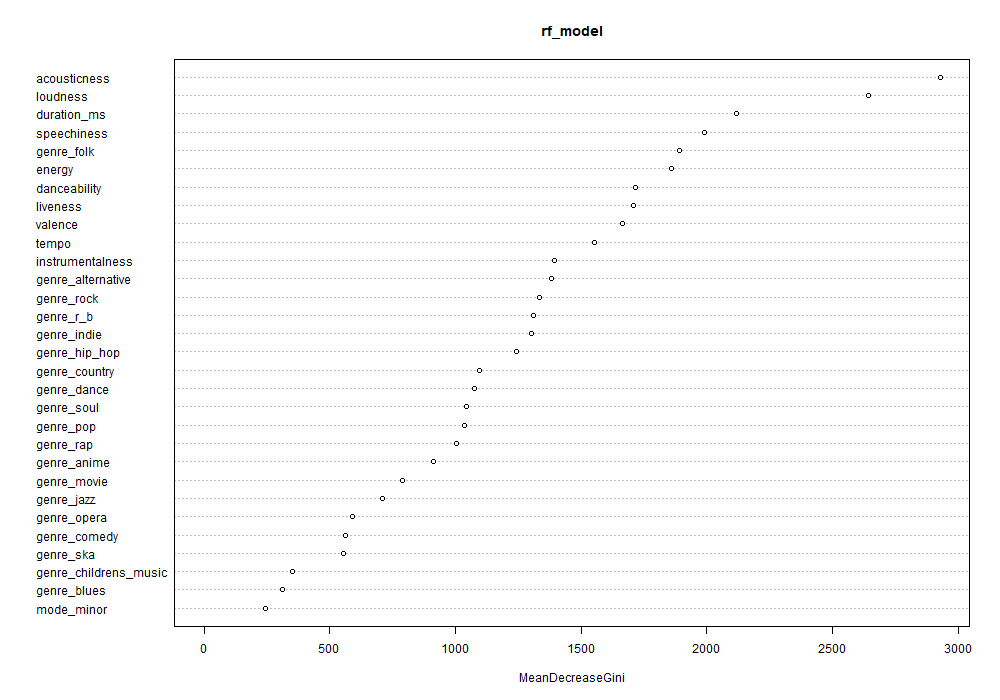

#### ANN

The neural network model captures complex, nonlinear relationships between song features and popularity. By passing inputs through hidden layers of interconnected nodes, the model can learn patterns that are not easily captured by linear or tree-based methods.

We specify a single hidden layer with five neurons, which provides sufficient flexibility to model nonlinear interactions. The model uses a logistic activation function (linear.output = FALSE) to produce probabilities between 0 and 1. Because neural networks are sensitive to the scale of inputs, all predictors are normalized prior to estimation.

```r
predictor_names <- setdiff(names(spotify_scale_train), "popular_binary")

ann_formula <- as.formula(
  paste("popular_binary ~", paste(predictor_names, collapse = " + ")))

set.seed(12345)
ann_model <- neuralnet(
  formula = ann_formula,
  data = spotify_scale_train,
  hidden = 5,
  stepmax = 1e6,
  linear.output = FALSE)
```

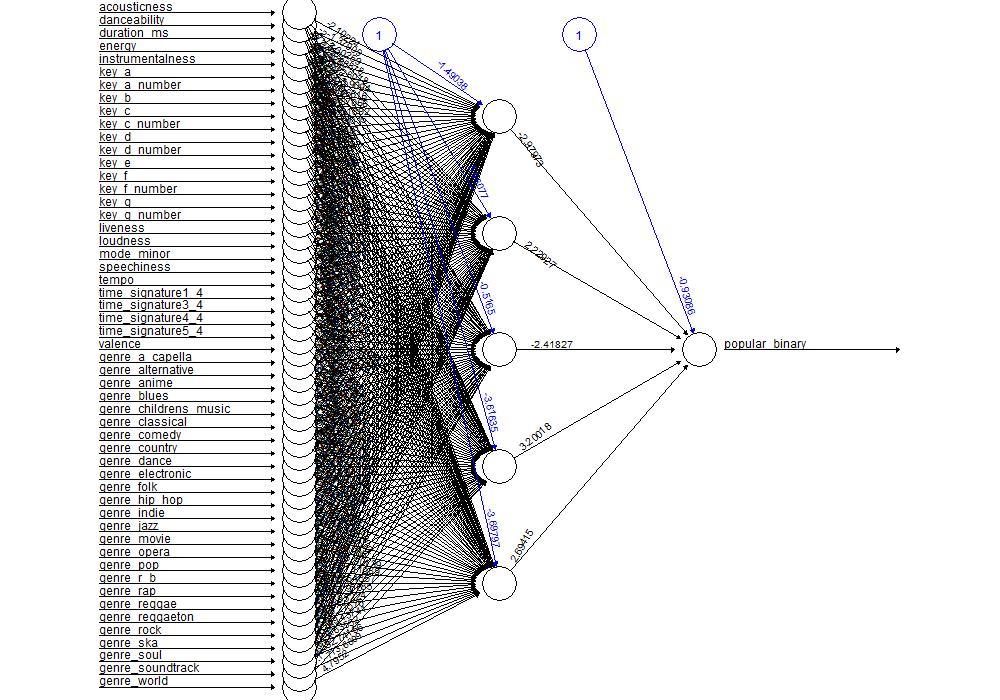

#### SVM

The support vector machine uses a kernel-based approach to classify songs by finding an optimal boundary that separates popular and non-popular tracks. We use a radial basis function (RBF) kernel, which allows the model to capture nonlinear relationships between predictors and the outcome. As with kNN and neural networks, predictors are scaled to ensure stable and meaningful distance calculations.

```r
set.seed(12345)
svmrbfdot_model <- ksvm(as.factor(popular_binary) ~ ., data = spotify_scale_train, kernel = "rbfdot", prob.model = TRUE)
```

#### Generating Predictions

Using the trained models, we generate predictions on the test dataset to evaluate out-of-sample performance. For each model, we obtain predicted probabilities that a song is classified as “popular.” These predicted probabilities are also used as inputs into the stacked model, allowing us to combine information across models. To facilitate evaluation, we also convert predicted probabilities into binary classifications using a threshold of 0.5, where songs with predicted probabilities above the threshold are classified as popular. For models that directly produce class labels, such as kNN and decision trees, we extract both the predicted classes and the associated probabilities where available.

##### Logistic Regression

```r
logistic_predictions <- predict(logistic_model, spotify_test, type = "response")
logistic_binpred <- ifelse(logistic_predictions >= 0.5, 1, 0)
```

##### KNN

For KNN, the prob attribute returns the proportion of neighbors voting for the predicted class. We transform this into the probability of being in the positive class (“popular”) to ensure consistency with other models.

```r
knn_prob <- attr(knn_model, "prob")
knn_predictions <- ifelse(as.character(knn_model) == "1", knn_prob, 1 - knn_prob)
summary(knn_predictions)
```

```
##    Min. 1st Qu.  Median    Mean 3rd Qu.    Max.
##  0.0000  0.1429  0.4286  0.5088  1.0000  1.0000
```

```r
rm(knn_prob)

knn_binpred <- knn_model
```

##### Decision Tree

```r
dt_pred <- predict(dt_model, spotify_test,  type = "prob")
dt_predictions <- dt_pred[, "1"]
summary(dt_predictions)
```

```
##    Min. 1st Qu.  Median    Mean 3rd Qu.    Max.
##  0.0131  0.2473  0.3207  0.5102  0.9815  0.9980
```

```r
dt_binpred <- predict(dt_model, spotify_test)
```

##### Random Forest

```r
rf_pred <- predict(rf_model,  spotify_test, type = "prob")
rf_predictions <- rf_pred[, "1"]
summary(rf_predictions)
```

```
##    Min. 1st Qu.  Median    Mean 3rd Qu.    Max.
##  0.0000  0.1740  0.4100  0.5052  0.9500  1.0000
```

```r
rf_binpred <- predict(rf_model,  spotify_test)
```

##### ANN

```r
# add any missing predictor columns as 0
missing_in_test <- setdiff(predictor_names, names(spotify_scale_test))
for (col in missing_in_test) {
  spotify_scale_test[[col]] <- 0
}

# reorder exactly to match training
ann_test_x <- spotify_scale_test[, predictor_names, drop = FALSE]

ann_pred <- neuralnet::compute(
  ann_model,
  ann_test_x
)$net.result

ann_predictions <- as.vector(ann_pred)
summary(ann_predictions)
```

```
##     Min.  1st Qu.   Median     Mean  3rd Qu.     Max.
## 0.001781 0.181770 0.427244 0.510825 0.985407 0.999249
```

```r
ann_binpred <- ifelse(ann_predictions >= 0.5, 1, 0)
```

##### SVM

```r
svm_pred <- predict(
  svmrbfdot_model, spotify_scale_test[, names(spotify_scale_test) != "popular_binary"],
  type = "prob")

svm_binpred <- predict(
  svmrbfdot_model, spotify_scale_test[, names(spotify_scale_test) != "popular_binary"],
  type = "response")

svm_predictions <- svm_pred[, "1"]
```

### Model Evaluation

To evaluate model performance, we compare accuracy, Kappa, and sensitivity across all six first-level models. These metrics provide complementary insights: accuracy reflects overall classification performance, Kappa adjusts for agreement due to chance, and sensitivity captures the model’s ability to correctly identify popular songs—our primary objective.

Across models, overall accuracy is relatively similar, ranging from approximately 81.2% to 83.4%. The random forest model achieves the highest accuracy (≈ 83.4%), with logistic regression, decision trees, ANN, and SVM performing comparably within a narrow band. However, accuracy alone masks meaningful differences in how models classify popular songs. When examining sensitivity, which is particularly important given our goal of identifying high-potential tracks, clearer distinctions emerge. The kNN model achieves the highest sensitivity (≈ 0.78), followed by the random forest and ANN models (≈ 0.75–0.76). Kappa values reinforce the overall ranking of model performance. The random forest model achieves the highest Kappa (≈ 0.67), suggesting it provides the most reliable predictions beyond chance, though the differences across models are relatively small.

Taken together, these results indicate that while many models achieve similar levels of overall accuracy, the random forest appears to be the strongest-performing individual model, offering the best balance between overall accuracy, reliability, and sensitivity.

```r
#logistic regression
logistic_confus <- confusionMatrix(
  factor(logistic_binpred, levels = c(0, 1)),
  factor(spotify_test$popular_binary, levels = c(0, 1)),
  positive = "1")

logistic_confus
```

```
## Confusion Matrix and Statistics
##
##           Reference
## Prediction     0     1
##          0 39322 11727
##          1  3718 33620
##
##                Accuracy : 0.8253
##                  95% CI : (0.8227, 0.8278)
##     No Information Rate : 0.5131
##     P-Value [Acc > NIR] : < 2.2e-16
##
##                   Kappa : 0.6519
##
##  Mcnemar's Test P-Value : < 2.2e-16
##
##             Sensitivity : 0.7414
##             Specificity : 0.9136
##          Pos Pred Value : 0.9004
##          Neg Pred Value : 0.7703
##              Prevalence : 0.5131
##          Detection Rate : 0.3804
##    Detection Prevalence : 0.4224
##       Balanced Accuracy : 0.8275
##
##        'Positive' Class : 1
##
```

```r
#knn
knn_confus <- confusionMatrix(
  factor(knn_binpred, levels = c(0, 1)),
  factor(spotify_test$popular_binary, levels = c(0, 1)),
  positive = "1")

knn_confus
```

```
## Confusion Matrix and Statistics
##
##           Reference
## Prediction     0     1
##          0 36500 10072
##          1  6540 35275
##
##                Accuracy : 0.8121
##                  95% CI : (0.8095, 0.8146)
##     No Information Rate : 0.5131
##     P-Value [Acc > NIR] : < 2.2e-16
##
##                   Kappa : 0.6246
##
##  Mcnemar's Test P-Value : < 2.2e-16
##
##             Sensitivity : 0.7779
##             Specificity : 0.8480
##          Pos Pred Value : 0.8436
##          Neg Pred Value : 0.7837
##              Prevalence : 0.5131
##          Detection Rate : 0.3991
##    Detection Prevalence : 0.4731
##       Balanced Accuracy : 0.8130
##
##        'Positive' Class : 1
##
```

```r
#decision tree
dt_confus <- confusionMatrix(
  factor(dt_binpred, levels = c(0, 1)),
  factor(spotify_test$popular_binary, levels = c(0, 1)),
  positive = "1"
)
dt_confus
```

```
## Confusion Matrix and Statistics
##
##           Reference
## Prediction     0     1
##          0 40001 12034
##          1  3039 33313
##
##                Accuracy : 0.8295
##                  95% CI : (0.827, 0.8319)
##     No Information Rate : 0.5131
##     P-Value [Acc > NIR] : < 2.2e-16
##
##                   Kappa : 0.6605
##
##  Mcnemar's Test P-Value : < 2.2e-16
##
##             Sensitivity : 0.7346
##             Specificity : 0.9294
##          Pos Pred Value : 0.9164
##          Neg Pred Value : 0.7687
##              Prevalence : 0.5131
##          Detection Rate : 0.3769
##    Detection Prevalence : 0.4113
##       Balanced Accuracy : 0.8320
##
##        'Positive' Class : 1
##
```

```r
#random forest
rf_confus <- confusionMatrix(
  factor(rf_binpred, levels = c(0, 1)),
  factor(spotify_test$popular_binary, levels = c(0, 1)),
  positive = "1"
)
rf_confus
```

```
## Confusion Matrix and Statistics
##
##           Reference
## Prediction     0     1
##          0 39347 10961
##          1  3693 34386
##
##                Accuracy : 0.8342
##                  95% CI : (0.8317, 0.8367)
##     No Information Rate : 0.5131
##     P-Value [Acc > NIR] : < 2.2e-16
##
##                   Kappa : 0.6696
##
##  Mcnemar's Test P-Value : < 2.2e-16
##
##             Sensitivity : 0.7583
##             Specificity : 0.9142
##          Pos Pred Value : 0.9030
##          Neg Pred Value : 0.7821
##              Prevalence : 0.5131
##          Detection Rate : 0.3890
##    Detection Prevalence : 0.4308
##       Balanced Accuracy : 0.8362
##
##        'Positive' Class : 1
##
```

```r
#ANN
ann_confus <- confusionMatrix(
  factor(ann_binpred, levels = c(0, 1)),
  factor(spotify_test$popular_binary, levels = c(0, 1)),
  positive = "1"
)
ann_confus
```

```
## Confusion Matrix and Statistics
##
##           Reference
## Prediction     0     1
##          0 39108 11091
##          1  3932 34256
##
##                Accuracy : 0.83
##                  95% CI : (0.8275, 0.8325)
##     No Information Rate : 0.5131
##     P-Value [Acc > NIR] : < 2.2e-16
##
##                   Kappa : 0.6613
##
##  Mcnemar's Test P-Value : < 2.2e-16
##
##             Sensitivity : 0.7554
##             Specificity : 0.9086
##          Pos Pred Value : 0.8970
##          Neg Pred Value : 0.7791
##              Prevalence : 0.5131
##          Detection Rate : 0.3876
##    Detection Prevalence : 0.4321
##       Balanced Accuracy : 0.8320
##
##        'Positive' Class : 1
##
```

```r
#SVM
svm_confus <- confusionMatrix(
  factor(svm_binpred, levels = c(0, 1)),
  factor(spotify_test$popular_binary, levels = c(0, 1)),
  positive = "1")
svm_confus
```

```
## Confusion Matrix and Statistics
##
##           Reference
## Prediction     0     1
##          0 40179 12367
##          1  2861 32980
##
##                Accuracy : 0.8277
##                  95% CI : (0.8252, 0.8302)
##     No Information Rate : 0.5131
##     P-Value [Acc > NIR] : < 2.2e-16
##
##                   Kappa : 0.6571
##
##  Mcnemar's Test P-Value : < 2.2e-16
##
##             Sensitivity : 0.7273
##             Specificity : 0.9335
##          Pos Pred Value : 0.9202
##          Neg Pred Value : 0.7646
##              Prevalence : 0.5131
##          Detection Rate : 0.3731
##    Detection Prevalence : 0.4055
##       Balanced Accuracy : 0.8304
##
##        'Positive' Class : 1
##
```

```r
#comparing first-level models
model_comparison <- data.frame(
  Model = c("Logistic", "kNN", "Decision Tree", "Random Forest", "ANN", "SVM"),
  Accuracy = c(
    logistic_confus$overall["Accuracy"],
    knn_confus$overall["Accuracy"],
    dt_confus$overall["Accuracy"],
    rf_confus$overall["Accuracy"],
    ann_confus$overall["Accuracy"],
    svm_confus$overall["Accuracy"]
  ),
  Kappa = c(
    logistic_confus$overall["Kappa"],
    knn_confus$overall["Kappa"],
    dt_confus$overall["Kappa"],
    rf_confus$overall["Kappa"],
    ann_confus$overall["Kappa"],
    svm_confus$overall["Kappa"]
  ),
  Sensitivity = c(
    logistic_confus$byClass["Sensitivity"],
    knn_confus$byClass["Sensitivity"],
    dt_confus$byClass["Sensitivity"],
    rf_confus$byClass["Sensitivity"],
    ann_confus$byClass["Sensitivity"],
    svm_confus$byClass["Sensitivity"]
  )
)

model_comparison
```

```
##           Model  Accuracy     Kappa Sensitivity
## 1      Logistic 0.8252571 0.6519236   0.7413941
## 2           kNN 0.8120538 0.6246349   0.7778905
## 3 Decision Tree 0.8294659 0.6605040   0.7346241
## 4 Random Forest 0.8342064 0.6696059   0.7582861
## 5           ANN 0.8300316 0.6612646   0.7554193
## 6           SVM 0.8277122 0.6571159   0.7272807
```

### Stacked Model Implementation

To further improve predictive performance, we implement stacked models, one with a cost matrix and one without, both of which use the predicted probabilities from the first-level models as inputs into a second-level decision tree. The goal of this approach is to allow the model to learn how to optimally combine the strengths of the individual models.

The intuition behind stacking is that different models capture different patterns in the data. By combining them, the stacked model can learn how to weight each model’s strengths, potentially improving overall performance. We estimate two versions of the stacked model: a probability-based model, which produces predicted probabilities and is used for ranking and resource allocation, and a cost-sensitive model, which prioritizes minimizing false negatives and is used for classification decisions.

```r
#creating dataframe of predictions across all models
stacked_df <- data.frame(
  logit_pred = as.numeric(logistic_predictions),
  knn_pred   = as.numeric(knn_predictions),
  ann_pred   = as.numeric(ann_predictions),
  svm_pred   = as.numeric(svm_predictions),
  tree_pred  = as.numeric(dt_predictions),
  rf_pred    = as.numeric(rf_predictions),
  y          = factor(spotify_test$popular_binary, levels = c(0, 1))
)

#splitting 70/30
ratio <- 0.7
set.seed(12345)
train_rows_stack <- sample(1:nrow(stacked_df), ratio*nrow(stacked_df))

#training and test sets for non-scaled data
stack_train <- stacked_df[train_rows_stack, ]
stack_test <- stacked_df[-train_rows_stack, ]
```

#### Stacked Model without Cost Matrix (Probability-Based)

The probability-based stacked model achieves performance similar to the best individual models. Accuracy, Kappa, and sensitivity are all comparable to those of the random forest, indicating that stacking provides only modest improvements in predictive performance.

Inspection of the tree structure reveals that the model relies heavily on the random forest predictions. This suggests that the random forest already captures most of the underlying signal, limiting the additional gains from combining models.

```r
#Probability model (no cost matrix)
stack_model_prob <- C5.0(
  x = stack_train[, names(stack_train) != "y"],
  y = stack_train$y)
summary(stack_model_prob)
```

```
##
## Call:
## C5.0.default(x = stack_train[, names(stack_train) != "y"], y = stack_train$y)
##
##
## C5.0 [Release 2.07 GPL Edition]      Wed Apr 22 00:33:56 2026
## -------------------------------
##
## Class specified by attribute `outcome'
##
## Read 61870 cases (7 attributes) from undefined.data
##
## Decision tree:
##
## tree_pred > 0.807031: 1 (21973/784)
## tree_pred <= 0.807031:
## :...rf_pred <= 0.194: 0 (16622/1098)
##     rf_pred > 0.194:
##     :...rf_pred <= 0.442: 0 (16116/5332)
##         rf_pred > 0.442:
##         :...rf_pred > 0.604: 1 (2249/681)
##             rf_pred <= 0.604:
##             :...rf_pred <= 0.492: 0 (2157/1024)
##                 rf_pred > 0.492: 1 (2753/1236)
##
##
## Evaluation on training data (61870 cases):
##
##      Decision Tree
##    ----------------
##    Size      Errors
##
##       6 10155(16.4%)   <<
##
##
##     (a)   (b)    <-classified as
##    ----  ----
##   27441  2701    (a): class 0
##    7454 24274    (b): class 1
##
##
##  Attribute usage:
##
##  100.00% tree_pred
##   64.49% rf_pred
##
##
## Time: 0.7 secs
```

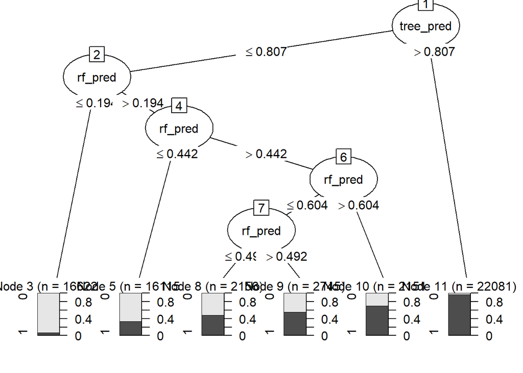

```r
plot(as.party(stack_model_prob))
```

```r
#predictions
stack_prob <- predict(
  stack_model_prob,
  stack_test[, names(stack_test) != "y"],
  type = "prob")[, "1"]

#creating binary from prediction
stack_pred_prob <- ifelse(stack_prob >= 0.5, 1, 0)

#confusion matrix
stack_confus_prob <- confusionMatrix(
  factor(stack_pred_prob, levels = c(0, 1)),
  factor(stack_test$y, levels = c(0, 1)),
  positive = "1")

stack_confus_prob
```

```
## Confusion Matrix and Statistics
##
##           Reference
## Prediction     0     1
##          0 11730  3296
##          1  1168 10323
##
##                Accuracy : 0.8317
##                  95% CI : (0.8271, 0.8361)
##     No Information Rate : 0.5136
##     P-Value [Acc > NIR] : < 2.2e-16
##
##                   Kappa : 0.6645
##
##  Mcnemar's Test P-Value : < 2.2e-16
##
##             Sensitivity : 0.7580
##             Specificity : 0.9094
##          Pos Pred Value : 0.8984
##          Neg Pred Value : 0.7806
##              Prevalence : 0.5136
##          Detection Rate : 0.3893
##    Detection Prevalence : 0.4333
##       Balanced Accuracy : 0.8337
##
##        'Positive' Class : 1
##
```

#### Stacked Model with Cost Matrix

To better align the model with the business objective of prioritizing the identification of popular songs, we implement a cost-sensitive stacked model. As in the baseline stacked approach, we use the predicted outputs from the first-level models as inputs into a second-level decision tree. However, in this specification, we incorporate a cost matrix that penalizes misclassification errors asymmetrically.

Specifically, we assign a higher cost to false negatives (predicting a song is not popular when it is actually popular) than to false positives. This reflects the managerial priority of minimizing missed opportunities for promoting songs with high potential. Because the C5.0 algorithm does not return class probabilities when a cost matrix is used, the model produces direct class predictions rather than probability estimates, and evaluation is based on classification outcomes.

Ultimately, the cost-sensitive stacked model achieves very high sensitivity, indicating that it successfully identifies nearly all truly popular songs. However, this comes at the expense of lower specificity and a reduction in overall accuracy. By heavily penalizing false negatives, the model becomes more likely to classify songs as popular, thereby capturing a larger share of high-potential tracks. While this increases the number of false positives, the associated cost is relatively small compared to the risk of missing a truly popular song.

```r
# create cost matrix
# rows = actual class, columns = predicted class
# higher cost for predicting 0 when actual is 1 (false negative)
cost_matrix <- matrix(
  c(0, 5,
    1, 0),
  nrow = 2,
  byrow = TRUE
)

colnames(cost_matrix) <- c("0", "1")
rownames(cost_matrix) <- c("0", "1")

# stacked model with cost matrix
stack_model_cost <- C5.0(
  x = stack_train[, names(stack_train) != "y"],
  y = stack_train$y,
  costs = cost_matrix
)

summary(stack_model_cost)
```

```
##
## Call:
## C5.0.default(x = stack_train[, names(stack_train) != "y"], y =
##  stack_train$y, costs = cost_matrix)
##
##
## C5.0 [Release 2.07 GPL Edition]      Wed Apr 22 00:34:01 2026
## -------------------------------
##
## Class specified by attribute `outcome'
##
## Read 61870 cases (7 attributes) from undefined.data
## Read misclassification costs from undefined.costs
##
## Decision tree:
##
## rf_pred > 0.64: 1 (23483/1199)
## rf_pred <= 0.64:
## :...rf_pred > 0.378: 1 (9366/4809)
##     rf_pred <= 0.378:
##     :...rf_pred > 0.218: 1 (11073/7575)
##         rf_pred <= 0.218:
##         :...ann_pred > 0.2360131: 1 (2008/1552)
##             ann_pred <= 0.2360131:
##             :...rf_pred <= 0.194: 0 (15378/836)
##                 rf_pred > 0.194:
##                 :...tree_pred <= 0.257544: 1 (515/423)
##                     tree_pred > 0.257544:
##                     :...svm_pred <= 0.2082492: 1 (13/9)
##                         svm_pred > 0.2082492: 0 (34/1)
##
##
## Evaluation on training data (61870 cases):
##
##         Decision Tree
##    -----------------------
##    Size      Errors   Cost
##
##       8 16404(26.5%)   0.32   <<
##
##
##     (a)   (b)    <-classified as
##    ----  ----
##   14575 15567    (a): class 0
##     837 30891    (b): class 1
##
##
##  Attribute usage:
##
##  100.00% rf_pred
##   29.01% ann_pred
##    0.91% tree_pred
##    0.08% svm_pred
##
##
## Time: 0.6 secs
```

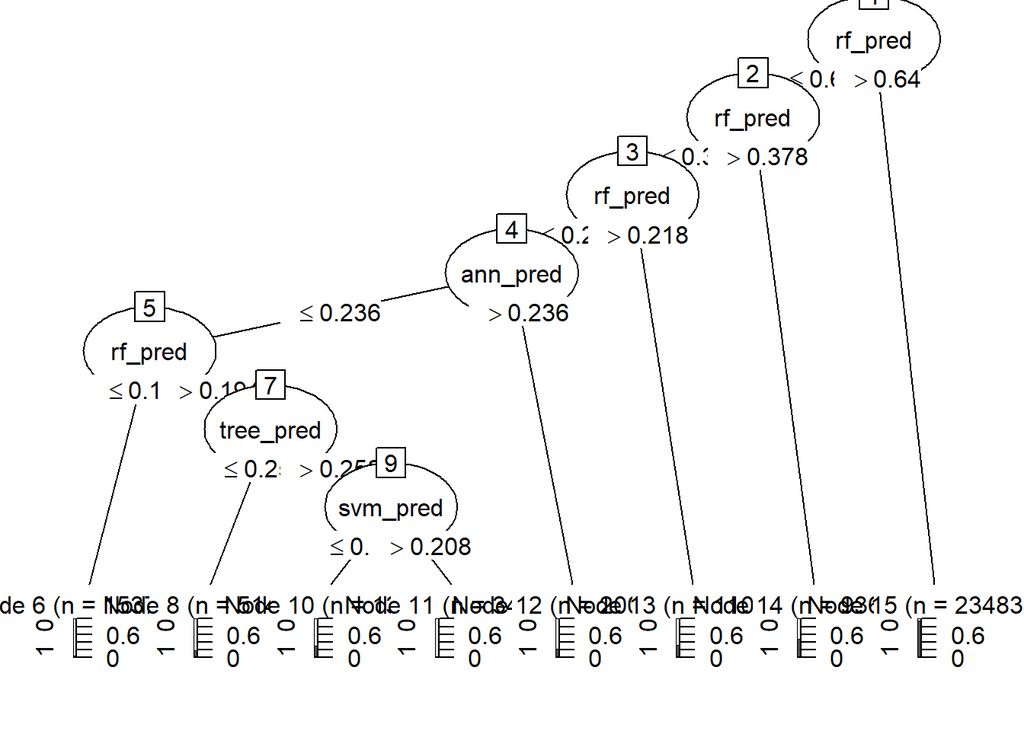

```r
plot(as.party(stack_model_cost))
```

```r
# predict classes directly
stack_pred_cost <- predict(
  stack_model_cost,
  stack_test[, names(stack_test) != "y"],
  type = "class"
)

# confusion matrix
stack_confus_cost <- confusionMatrix(
  factor(stack_pred_cost, levels = c("0", "1")),
  factor(stack_test$y, levels = c("0", "1")),
  positive = "1"
)

stack_confus_cost
```

```
## Confusion Matrix and Statistics
##
##           Reference
## Prediction     0     1
##          0  6098   423
##          1  6800 13196
##
##                Accuracy : 0.7276
##                  95% CI : (0.7222, 0.733)
##     No Information Rate : 0.5136
##     P-Value [Acc > NIR] : < 2.2e-16
##
##                   Kappa : 0.4476
##
##  Mcnemar's Test P-Value : < 2.2e-16
##
##             Sensitivity : 0.9689
##             Specificity : 0.4728
##          Pos Pred Value : 0.6599
##          Neg Pred Value : 0.9351
##              Prevalence : 0.5136
##          Detection Rate : 0.4976
##    Detection Prevalence : 0.7541
##       Balanced Accuracy : 0.7209
##
##        'Positive' Class : 1
##
```

Overall, the stacked models demonstrate two important insights. First, combining models can yield modest improvements in predictive performance, but may not outperform a strong individual model when one dominates (as seen with the random forest). Second, incorporating business priorities through a cost matrix meaningfully shifts model behavior by prioritizing sensitivity. The cost-sensitive stacked model achieves very high sensitivity (≈ 0.969), indicating that it successfully identifies nearly all truly popular songs. However, this comes at the expense of substantially lower accuracy (≈ 0.728) and Kappa (≈ 0.448), reflecting a decline in overall predictive reliability. This highlights a clear tradeoff: improving the model’s ability to capture high-potential songs increases the likelihood of false positives and reduces overall classification performance.

```r
#adding stacked model for model comparison
model_comparison <- rbind(
  model_comparison,
  data.frame(
    Model = "Stacked (Prob, 0.5 threshold)",
    Accuracy = stack_confus_prob$overall["Accuracy"],
    Kappa = stack_confus_prob$overall["Kappa"],
    Sensitivity = stack_confus_prob$byClass["Sensitivity"]),
  data.frame(
    Model = "Stacked (Cost Sensitive)",
    Accuracy = stack_confus_cost$overall["Accuracy"],
    Kappa = stack_confus_cost$overall["Kappa"],
    Sensitivity = stack_confus_cost$byClass["Sensitivity"]
  )
)
model_comparison
```

```
##                                   Model  Accuracy     Kappa Sensitivity
## 1                              Logistic 0.8252571 0.6519236   0.7413941
## 2                                   kNN 0.8120538 0.6246349   0.7778905
## 3                         Decision Tree 0.8294659 0.6605040   0.7346241
## 4                         Random Forest 0.8342064 0.6696059   0.7582861
## 5                                   ANN 0.8300316 0.6612646   0.7554193
## 6                                   SVM 0.8277122 0.6571159   0.7272807
## Accuracy  Stacked (Prob, 0.5 threshold) 0.8316552 0.6645263   0.7579852
## Accuracy1      Stacked (Cost Sensitive) 0.7276087 0.4475847   0.9689405
```

### Business Application

#### Value of Model-Based Ranking vs. Heuristic Decision Rules

While traditional evaluation metrics such as accuracy and sensitivity are useful, they do not fully capture how models create value in practice. In real-world settings, music platforms and record labels must prioritize which songs to promote, rather than simply classify them. As a result, the most relevant question is not whether the model correctly labels every song, but whether it improves the ranking of songs by potential success. If the highest-ranked songs are more likely to succeed than those selected using simpler decision rules, the model can materially improve the return on limited promotional resources.

To evaluate this, we compare the model’s ranking performance to a realistic business benchmark: an audio-feature heuristic based on commonly used indicators of commercial appeal.

##### Underlying Assumptions

To translate model performance into business value, we make the following assumptions:

- A song is considered “successful” if it is classified as popular (above the median threshold).
- The model-based strategy ranks songs using predicted probabilities.
- The heuristic benchmark ranks songs using a simplified score based on observable audio features.
- Business value is driven by improving the share of promoted songs that are successful.
- External factors (e.g., artist reputation, marketing spend, viral trends) are not explicitly modeled.

##### Simulation Overview

We evaluate the model as a ranking tool, reflecting how decisions are made in practice. Songs are sorted from highest to lowest predicted probability of success, and performance is evaluated by examining how success rates vary across ranked groups. We compare this approach to a heuristic strategy based on widely accepted indicators of commercial appeal, including higher danceability, energy, and loudness, and lower acousticness and instrumentalness. This heuristic represents a realistic baseline: it captures intuitive decision-making but cannot account for complex relationships between features. The comparison therefore isolates the incremental value of a data-driven model.

##### Build the audio-feature heuristic benchmark

Next, we construct a more realistic non-model benchmark. Instead of comparing the model to random selection, we compare it to a simple rule a business might plausibly use without machine learning: prioritizing songs based on their audio characteristics.

Specifically, we create a heuristic score that rewards songs with higher danceability, higher energy, and greater loudness, while penalizing songs with higher acousticness and instrumentalness. These features are commonly associated with mainstream commercial appeal and playlist performance.

The heuristic is intentionally simple and does not attempt to capture complex interactions between variables. This makes it a useful baseline for evaluating whether the full predictive model adds value beyond intuitive audio-based rules of thumb.

```r
heuristic_vars <- c("danceability", "energy", "loudness", "acousticness", "instrumentalness")

# compute train means + sds (for proper scaling)
train_stats <- spotify_train %>%
  summarise(
    across(all_of(heuristic_vars),
           list(mean = ~mean(.x, na.rm = TRUE),
                sd   = ~sd(.x, na.rm = TRUE)))
  )

# helper for z-scoring using train stats
z_from_train <- function(x, mean_val, sd_val) {
  if (sd_val == 0) return(rep(0, length(x)))
  (x - mean_val) / sd_val
}
```

##### Rank songs using the audio-based heurisitc

To make the value of the model more concrete, we compare the model-based ranking to an audio-feature heuristic benchmark. Under this strategy, songs are prioritized using a simple score that rewards higher danceability, energy, and loudness, while penalizing higher acousticness and instrumentalness. If the model is useful in practice, the top-ranked deciles under the model should contain a larger share of truly popular songs than the top-ranked deciles under this simpler heuristic.

```r
# rows in spotify_test that correspond to stack_test
spotify_test_stackholdout <- spotify_test[-train_rows_stack, ]

audio_heuristic_df <- spotify_test_stackholdout %>%
  mutate(
    danceability_z = z_from_train(danceability, train_stats$danceability_mean, train_stats$danceability_sd),
    energy_z       = z_from_train(energy, train_stats$energy_mean, train_stats$energy_sd),
    loudness_z     = z_from_train(loudness, train_stats$loudness_mean, train_stats$loudness_sd),
    acousticness_z = z_from_train(acousticness, train_stats$acousticness_mean, train_stats$acousticness_sd),
    instrumentalness_z = z_from_train(instrumentalness, train_stats$instrumentalness_mean, train_stats$instrumentalness_sd),

    actual_popular = popular_binary,
    #the heuristic score
    heuristic_score = danceability_z + energy_z + loudness_z - acousticness_z - instrumentalness_z
  ) %>%
  arrange(desc(heuristic_score)) %>%
  mutate(heuristic_rank = row_number(), heuristic_decile = ntile(heuristic_rank, 10))

audio_heuristic_decile_summary <- audio_heuristic_df %>%
  group_by(heuristic_decile) %>%
  summarise(
    Songs = n(),
    Popular_Songs = sum(actual_popular == 1),
    Success_Rate = mean(actual_popular == 1),
    .groups = "drop"
  ) %>%
  arrange(heuristic_decile)
```

##### Rebuild the final model-based comparison on the original test observations

To ensure the comparison is fair, we now rebuild the model-based business dataset using the original test observations, which include the same songs used in the heuristic benchmark. We then compare success rates by decile across the two strategies and visualize how much better the model is at concentrating successful songs near the top of the ranking.

```r
# final model probabilities from stacked model
final_prob <- stack_prob

# model-based business dataset on same observations as stack_prob
business_df <- spotify_test_stackholdout %>%
  mutate(
    predicted_prob = final_prob,
    actual_popular = popular_binary
  ) %>%
  arrange(desc(predicted_prob)) %>%
  mutate(
    rank = row_number(),
    decile = ntile(rank, 10)
  )

decile_summary <- business_df %>%
  group_by(decile) %>%
  summarise(
    Songs = n(),
    Popular_Songs = sum(actual_popular == 1),
    Success_Rate = mean(actual_popular == 1),
    .groups = "drop"
  ) %>%
  arrange(decile)

overall_rate <- mean(business_df$actual_popular == 1)

comparison_df <- decile_summary %>%
  select(decile, Model_Success_Rate = Success_Rate) %>%
  left_join(
    audio_heuristic_decile_summary %>%
      transmute(decile = heuristic_decile,
                Audio_Heuristic_Success_Rate = Success_Rate),
    by = "decile"
  )

comparison_df
```

```
## # A tibble: 10 × 3
##    decile Model_Success_Rate Audio_Heuristic_Success_Rate
##     <int>              <dbl>                        <dbl>
##  1      1             0.963                         0.654
##  2      2             0.965                         0.640
##  3      3             0.963                         0.660
##  4      4             0.817                         0.629
##  5      5             0.460                         0.602
##  6      6             0.335                         0.530
##  7      7             0.332                         0.473
##  8      8             0.157                         0.447
##  9      9             0.0717                        0.256
## 10     10             0.0713                        0.246
```

##### Key Results

The comparison shows that the stacked model creates much stronger separation between high- and low-potential songs than the heuristic model. In the top decile, the model achieves a success rate of approximately 96.3%, compared to 65.4% under the heuristic. This represents a dramatic improvement in the concentration of successful songs among top-ranked selections. At the same time, it assigns much lower success rates to the bottom deciles, indicating that it is also more effective at identifying songs with low potential. This sharper ranking is valuable for allocating limited promotional resources, because it allows decision-makers to focus attention on the songs most likely to succeed.

While these results demonstrate strong ranking performance, their true importance lies in how they translate into financial outcomes.

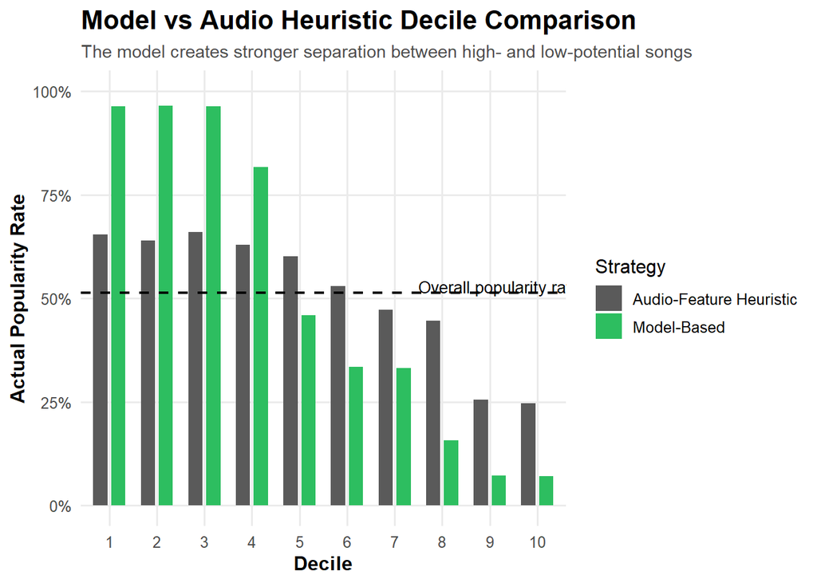

```r
# ggplot(comparison_df, aes(x = decile)) +
#   geom_line(aes(y = Model_Success_Rate, linetype = "Model-Based Ranking"), linewidth = 1) +
#   geom_point(aes(y = Model_Success_Rate), size = 2) +
#   geom_line(aes(y = Audio_Heuristic_Success_Rate, linetype = "Audio-Feature Heuristic"), linewidth = 1) +
#   geom_point(aes(y = Audio_Heuristic_Success_Rate), size = 2) +
#   geom_hline(yintercept = overall_rate, linetype = "dashed") +
#   scale_y_continuous(labels = scales::percent_format(accuracy = 1)) +
#   scale_x_continuous(breaks = 1:10) +
#   labs(
#     title = "Which Strategy Better Prioritizes Songs for Promotion?",
#     subtitle = "Success rate by decile of ranked songs",
#     x = "Decile (1 = highest ranked songs)",
#     y = "Actual popularity rate",
#     linetype = ""
#   ) +
#   theme_spotify()

library(dplyr)
library(tidyr)
library(ggplot2)
library(scales)

# reshape for grouped bar chart
plot_df <- comparison_df %>%
  rename(
    `Model-Based` = Model_Success_Rate,
    `Audio-Feature Heuristic` = Audio_Heuristic_Success_Rate
  ) %>%
  pivot_longer(
    cols = c(`Model-Based`, `Audio-Feature Heuristic`),
    names_to = "Strategy",
    values_to = "Success_Rate"
  ) %>%
  mutate(
    decile = factor(decile, levels = 1:10)
  )

ggplot(plot_df, aes(x = decile, y = Success_Rate, fill = Strategy)) +
  geom_col(
    position = position_dodge(width = 0.75),
    width = 0.6
  ) +
  geom_hline(
    yintercept = overall_rate,
    linetype = "dashed",
    linewidth = 0.8,
    color = "black"
  ) +
  annotate(
    "text",
    x = 7.5,
    y = overall_rate + 0.015,
    label = paste0("Overall popularity rate = ", percent(overall_rate, accuracy = 0.1)),
    hjust = 0,
    size = 3.5,
    color = "black"
  ) +
  scale_fill_manual(
    values = c(
      "Model-Based" = "#2DBE60",
      "Audio-Feature Heuristic" = "#5A5A5A"
    )
  ) +
  scale_y_continuous(
    labels = percent_format(accuracy = 1),
    limits = c(0, 1)
  ) +
  labs(
    title = "Model vs Audio Heuristic Decile Comparison",
    subtitle = "The model creates stronger separation between high- and low-potential songs",
    x = "Decile",
    y = "Actual Popularity Rate",
    fill = "Strategy"
  ) +
  theme_minimal(base_size = 12) +
  theme(
    plot.title = element_text(face = "bold", size = 16),
    plot.subtitle = element_text(size = 11, color = "gray30"),
    axis.title = element_text(face = "bold"),
    legend.position = "right",
    panel.grid.minor = element_blank()
  )
```

#### Economic Value of Improved Song Selection

While the model is useful statistically, its real value comes from improving business decisions. To illustrate the economic value of the model, consider a simplified scenario in which a label must decide which songs to promote. Suppose that: a major promotional campaign costs $100,000 per song, a successfully promoted song generates $500,000 in revenue, and the label can only heavily promote a limited number of songs. Under these conditions, the key driver of profitability is the success rate of promoted songs.

Our ranking analysis suggests that the top decile of songs selected by the model has a success rate of approximately 96.3%, compared with 65.4% for the simpler audio-feature heuristic benchmark. This implies that the model substantially improves the probability that a promoted song will actually succeed.

We can translate this improvement into expected financial value. The expected revenue from promoting one song can be expressed as: Expected Revenue = P(Success) × Revenue from a Successful Song. The expected profit is then: Expected Profit = (P(Success) × Revenue from a Successful Song) − Promotion Cost.

Using the assumptions above, under the Heuristic strategy: (0.654×500,000)−100,000=227,000. Under the model-based strategy: (0.963×500,000)−100,000=381,500. This implies an expected profit increase of $154,500 per promoted song from using the model rather than the simpler heuristic.

Even if these revenue assumptions are approximate, the broader implication is clear: if promotional resources are scarce, using the model to rank songs can materially improve return on investment by concentrating spending on songs with the highest likelihood of success. At scale, the gains could be substantial. For example, if a label makes 20 major promotional decisions in a year, an expected improvement of $154,500 per decision would imply over $3 million in additional expected profit annually.

```r
# Economic value / ROI illustration

promotion_cost <- 100000
success_revenue <- 500000

model_success_rate <- decile_summary$Success_Rate[decile_summary$decile == 1]
heuristic_success_rate <- audio_heuristic_decile_summary$Success_Rate[
  audio_heuristic_decile_summary$heuristic_decile == 1
]

roi_summary <- tibble::tibble(
  Strategy = c("Model-Based Ranking", "Audio-Feature Heuristic"),
  Success_Rate = c(model_success_rate, heuristic_success_rate),
  Expected_Revenue = Success_Rate * success_revenue,
  Promotion_Cost = promotion_cost,
  Expected_Profit = Expected_Revenue - Promotion_Cost
)

kable(
  roi_summary %>%
    mutate(
      Success_Rate = scales::percent(Success_Rate, accuracy = 0.1),
      Expected_Revenue = scales::dollar(Expected_Revenue),
      Promotion_Cost = scales::dollar(Promotion_Cost),
      Expected_Profit = scales::dollar(Expected_Profit)
    ),
  caption = "Illustrative expected value of model-based promotion decisions"
)
```

Illustrative expected value of model-based promotion decisions

| Strategy | Success_Rate | Expected_Revenue | Promotion_Cost | Expected_Profit |
| --- | --- | --- | --- | --- |
| Model-Based Ranking | 96.3% | $481,712 | $100,000 | $381,712 |
| Audio-Feature Heuristic | 65.4% | $327,112 | $100,000 | $227,112 |

```r
profit_gain <- (model_success_rate - heuristic_success_rate) * success_revenue
paste0(
  "Expected profit increase per promoted song from using the model: ",
  scales::dollar(profit_gain)
)
```

```
## [1] "Expected profit increase per promoted song from using the model: $154,600"
```

##### Key Takeaways

This result highlights a critical insight: the model does not need to be perfect to create value. It only needs to improve decision quality at the margin. Because promotional costs are fixed and upside is concentrated among successful songs, even moderate improvements in selection accuracy produce large financial gains. This is especially important in the music industry, where outcomes are highly skewed and a small number of hits generate a disproportionate share of revenue.

The comparison between the probability-based and cost-sensitive stacked models highlights an important managerial insight: model choice should depend on the decision context. While probability-based models are useful for ranking and resource allocation, cost-sensitive models are better suited for decision environments where certain types of errors are more costly than others.

##### Summary Metrics

To complement this financial interpretation, we summarize the model’s ranking performance using standard lift-based metrics.

To summarize performance, we evaluate overall success rates and ranking lift. The stacked model achieves a top-decile lift of approximately 1.88x, meaning songs in the highest-ranked group are nearly twice as likely to succeed as the average song. This highlights the model’s ability to concentrate success within a small subset of candidates, which is essential in environments where only a limited number of songs can be promoted.

From a business perspective, this type of lift translates directly into improved decision-making: fewer resources are wasted on low-potential songs, and more resources are directed toward those most likely to succeed.

```r
summary_metrics <- data.frame(
  Metric = c(
    "Overall test-set popularity rate",
    "Top decile popularity rate (model)",
    "Top decile popularity rate (audio heuristic)",
    "Bottom decile popularity rate (model)"
  ),
  Value = c(
    overall_rate,
    decile_summary$Success_Rate[decile_summary$decile == 1],
    audio_heuristic_decile_summary$Success_Rate[audio_heuristic_decile_summary$heuristic_decile == 1],
    decile_summary$Success_Rate[decile_summary$decile == 10]
  )
)

lift_metric <- decile_summary$Success_Rate[decile_summary$decile == 1] / overall_rate

summary_metrics %>%
  mutate(Value = scales::percent(Value, accuracy = 0.1))
```

```
##                                         Metric Value
## 1             Overall test-set popularity rate 51.4%
## 2           Top decile popularity rate (model) 96.3%
## 3 Top decile popularity rate (audio heuristic) 65.4%
## 4        Bottom decile popularity rate (model)  7.1%
```

```r
paste0("Top-decile lift vs. overall: ", round(lift_metric, 2), "x")
```

```
## [1] "Top-decile lift vs. overall: 1.88x"
```

### Managerial Implications for Spotify and Record Labels

Building on these findings, the model provides several actionable insights for Spotify and record labels:

1. Informing Music Production Decisions: The model results suggest that certain audio features, particularly danceability and energy, are strong predictors of song popularity. This has clear implications for artists and producers: labels should prioritize these attributes during production and mixing. In contrast, features such as tempo (BPM) appear to have limited predictive power, indicating that labels should avoid over-optimizing around specific BPM targets and instead focus on overall feel and engagement.
2. Optimizing Marketing and Promotion Strategy: One of the most immediate applications of the model is in resource allocation for marketing and promotion because songs predicted to have high popularity should receive greater promotional investment, including playlist pitching, social media campaigns, and advertising spend, relative to those predicted to have lower popularity. This approach enables labels to prioritize high-ROI opportunities, rather than distributing marketing budgets evenly across all releases.
3. Supporting Portfolio Strategy for Record Labels: Labels can evaluate multiple unreleased tracks and rank them based on predicted popularity, selecting the most promising candidates for lead singles.
4. Reducing Risk in New Releases: The music industry is inherently uncertain, with a small number of songs generating a disproportionate share of revenue. This model helps mitigate that uncertainty by providing an ex-ante estimate of performance, allowing stakeholders to make more informed decisions before release.

To operationalize these insights, organizations could integrate the model into internal dashboards for their A&R (Artists & Repertoire) teams and use the predictions as part of go/no-go decisions for marketing spend.

### Risks and Limitations

While the model demonstrates strong predictive performance and clear business value, several limitations should be considered when interpreting the results and applying the model in practice.

First, the model relies exclusively on observable song characteristics and genre indicators. It does not incorporate important external factors such as artist reputation or marketing spend. These omitted variables can play a significant role in determining a song’s success, meaning the model may underperform in real-world settings.

Second, the definition of “success” in this analysis is based on a median split of Spotify popularity. While this creates a balanced classification problem, it simplifies a complex outcome. In practice, business value is often driven by extreme success (e.g., top-charting songs), not just being above the median. As a result, the model may not fully capture the dynamics of true breakout hits. Third, the model is trained and evaluated on historical data, which assumes that relationships between song characteristics and popularity remain stable over time. However, music trends evolve quickly, and features associated with popularity today may not generalize to future releases.

Finally, the cost-sensitive model intentionally prioritizes sensitivity at the expense of specificity. While this aligns with the business goal of avoiding missed opportunities, it leads to a higher rate of false positives. In practice, this could result in allocating promotional resources to songs that do not ultimately perform well, which may reduce efficiency if resources are highly constrained.

### Conclusion

This analysis demonstrates that song popularity is not purely random, but is systematically related to measurable audio characteristics and genre patterns. While no model perfectly predicts success, the results show that machine learning approaches can meaningfully improve the identification of high-potential songs.

The primary source of business value is not perfect classification, but improved ranking and prioritization. By concentrating promotional resources on the highest-scoring songs, the model increases the likelihood that promoted tracks will succeed, leading to more efficient marketing spend and stronger portfolio performance.

The economic analysis reinforces this point: even modest improvements in selection accuracy translate into substantial financial gains in a hit-driven industry. This highlights a key managerial insight—predictive models do not need to be perfect to be valuable; they only need to improve decisions at the margin.